# Drzewa decyzyjne

Michał‚ Stawikowski

24 - 04 - 2019

```r
knitr::opts_chunk$set(cache=TRUE)
```

# 1 Wstęp

W tym raporcie przyjrzę się algorytmowi drzewa decyzyjnego, a konktretnie `R`-owej implementacji `rpart`. Przeanalizujemy i omówimy wnioski pochodzące z [artykułu](https://arxiv.org/pdf/1802.09596.pdf) na temat optymalnego zbioru himperparametrów dla algorytmu `rpart` na zbiorze danych `Titanic`. Zwizualizuję wytrenowawane drzewa oraz zbadam wpływ kryterium podziału na powstałe reguły decyzyjne. Na koniec zbadam czym różnią sie wczesniej omawiane drzewa od `Conditional Inference Trees`.

# 2 Porównanie ustawień hiperparametrów

W wyżej wymienionym artykule do strojenia zostały wybrane parametry:

- `cp` - ‘parametr złożoności’, który zapobiega dokonywania nic nie wnoszących podziałów
- `maxdepth` - maksymalna głębokość drzewa
- `minbucket` - minimalna liczba obserwacji w liściu ‘terminalnym’
- `minsplit` - minimalna liczba obserwacji w węźle umożliwiająca jego podział

W strojenie skupimy się na tych parametrach i porównamy te proponowane domyślnie przez pakiet `rpart`, te otrzymane przez autorów raportu w wyniku szukania optymalnych ustawień oraz te znalezione dzięki `random search`. Do oceny wyników będziemy używali 5-krotnej kroswalidacji. Tak jak autorzy wcześniej wymienionej pracy skupimy się na miarach `AUC` i `ACC`.

## 2.1 Ustawienia domyślne

```r
classif_task = makeClassifTask(id = "task", data = data, target = "survived")
classif_lrn = makeLearner("classif.rpart", predict.type = "prob")

cv <- makeResampleDesc("CV", iters = 5)
r <- resample(classif_lrn, classif_task, cv, measures = list(acc, auc))

measure <- r$aggr
measure
```

```
## acc.test.mean auc.test.mean
##     0.8010927     0.7636189
```

## 2.2 Random search

Hiperparametrów będziemy szukać na tej samej przestrzeni co autorzy artykułu. Wykonamy 50 iteracji losowego szukania najlepszych parametrów.

```r
classif_task = makeClassifTask(id = "task", data = data, target = "survived")
classif_lrn = makeLearner("classif.rpart", predict.type = "prob")

num_ps = makeParamSet(
  makeIntegerParam("cp", lower = 0, upper = 1),
  makeIntegerParam("maxdepth", lower = 1, upper = 30),
  makeIntegerParam("minbucket", lower = 1, upper = 60),
  makeIntegerParam("minsplit", lower = 1, upper = 60)
)

ctrl = makeTuneControlRandom(maxit = 50L)
rdesc = makeResampleDesc("CV", iters = 5L)



res5 = tuneParams(classif_lrn, task = classif_task, resampling = rdesc,
                  par.set = num_ps, control = ctrl, measures = list(auc,acc))

res5
```

```
## Tune result:
## Op. pars: cp=0; maxdepth=29; minbucket=2; minsplit=45
## auc.test.mean=0.7981943,acc.test.mean=0.7856917
```

## 2.3 Optymalny zestaw

```r
classif_task2 = makeClassifTask(id = "task", data = data, target = "survived")
classif_lrn2 = makeLearner("classif.rpart", predict.type = "prob", par.vals = list("cp" = 0, "maxdepth" = 21,
                                                                                  "minbucket" = 12, "minsplit" = 24))

cv2 <- makeResampleDesc("CV", iters = 5)
r2 <- resample(classif_lrn2, classif_task2, cv2, measures = list(acc, auc))

measure2 <- r2$aggr
measure2
```

```
## acc.test.mean auc.test.mean
##     0.7915761     0.8007176
```

Najlepiej pod względem `AUC` poradził sobie zestaw hiperparametrów propownowany przez autorów artykułu. Minimalnie gorzej wypadł wynik uzyskany przy parametrach znalezionych losowo przy 50 iteracjach. W dwóch ostatnich przykładach widać znaczną poprawę `AUC` w porównaniu do domyślnego ustawienia z pakietu. Jednak pod względem `ACC` najlepiej wypadł wynik uzyskany przy pierwszym ustawieniu. Możliwe, że parametry proponowane w pakiecie zostały wybierane pod względem `accuracy`, a nie `AUC` jak dwa pozostałe ustawinia parametrów.

# 3 Wizualizacja najlepszego drzewa

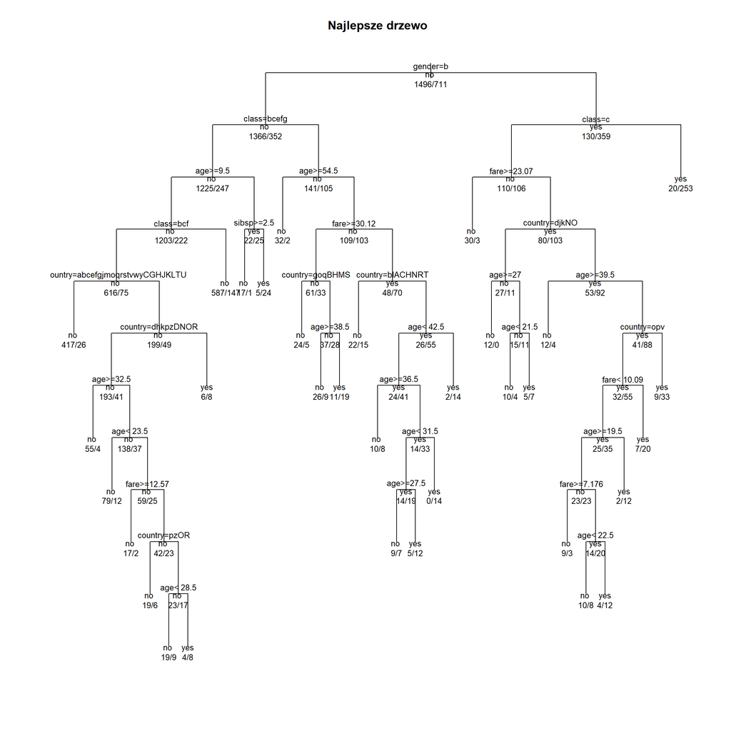

```r
tree <- rpart(survived~., data=data, cp = 0, maxdepth = 21, minbucket = 12, minsplit = 24)

plot(tree, uniform=TRUE,
   main="Najlepsze drzewo")
text(tree, use.n=TRUE, all=TRUE, cex=.8)
```

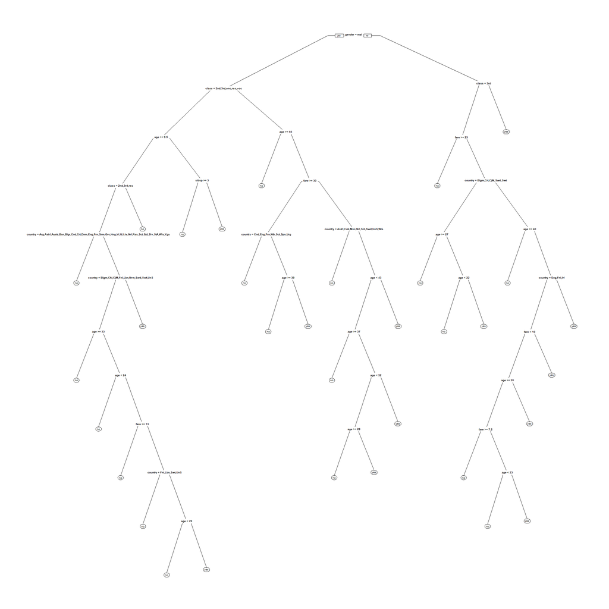

```r
prp(tree)
```

# 4 Kryterium podziału

## 4.1 Information Gain

`Przyrost informacji` jest używany przy wybieraniu zmiennych, według których nastąpi podział na każdym etapie w trakcie budowania drzewa.

```r
classif_task2 = makeClassifTask(id = "task", data = data, target = "survived")
classif_lrn2 = makeLearner("classif.rpart", predict.type = "prob", par.vals = list("cp" = 0, "maxdepth" = 21,
                                                                                  "minbucket" = 12, "minsplit" = 24),parms = list(split = 'information'))

cv2 <- makeResampleDesc("CV", iters = 5)
r2 <- resample(classif_lrn2, classif_task2, cv2, measures = list(acc, auc))

measure2 <- r2$aggr
measure2
```

```
## acc.test.mean auc.test.mean
##     0.7960907     0.7951630
```

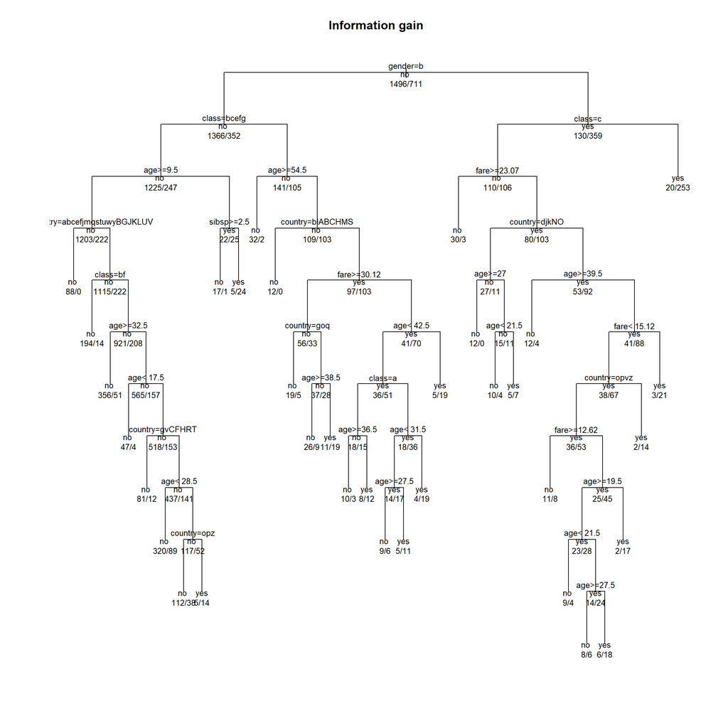

```r
tree <- rpart(survived~., data=data, cp = 0, maxdepth = 21, minbucket = 12, minsplit = 24, parms = list(split = 'information'))

plot(tree, uniform=TRUE, main="Information gain")
text(tree, use.n=TRUE, all=TRUE, cex=.8)
```

## 4.2 Gini

Wskażnik `Gini impurity` liczymy ze wzoru:

$1 - \sum^{J}_{i=1} {p_i}^{2}$

Gdzie $J$ to zbiór wszystkich klas, a ${p_i}$ oznacza frakcje obiektów z klasy $i$-tej. Funkcja osiąga minimum, gdy wszystkie obiekty w węźlę należą do jednej klasy. To kryterium preferuje większe podziały i jest bardzo proste do zaimplementowania i nie wymaga tak dużo czasu do policzenia jak `Entropia`, którą wyzncza się przy `Information gain`.

```r
classif_task2 = makeClassifTask(id = "task", data = data, target = "survived")
classif_lrn2 = makeLearner("classif.rpart", predict.type = "prob", par.vals = list("cp" = 0, "maxdepth" = 21,
                                                                                  "minbucket" = 12, "minsplit" = 24),parms = list(split = 'gini'))

cv2 <- makeResampleDesc("CV", iters = 5)
r2 <- resample(classif_lrn2, classif_task2, cv2, measures = list(acc, auc))

measure2 <- r2$aggr
measure2
```

```
## acc.test.mean auc.test.mean
##     0.7924821     0.7867791
```

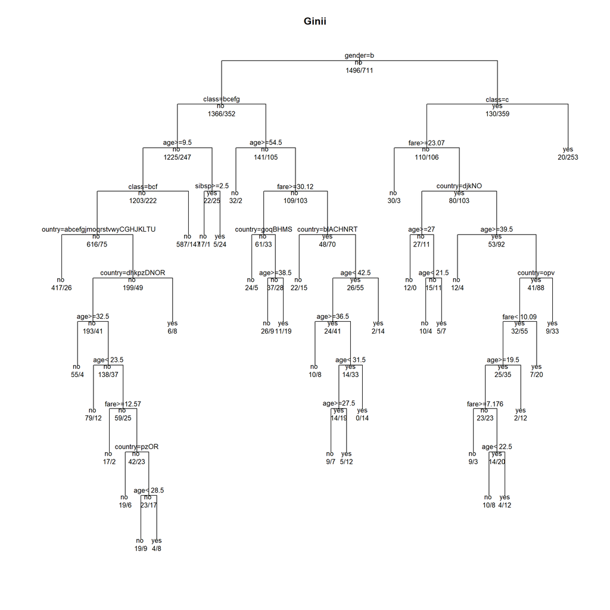

```r
tree <- rpart(survived~., data=data, cp = 0, maxdepth = 21, minbucket = 12, minsplit = 24, parms = list(split = 'gini'))

plot(tree, uniform=TRUE, main="Ginii")
text(tree, use.n=TRUE, all=TRUE, cex=.8)
```

“Studies have shown that the choice of impurity measure has little effect on the performance of decision tree induction algorithms. This is because many impurity measures are quite consistent with each other […].”

# 5 Conditional Inference Trees - ctree

Główną różnica pomiędzy `ctree` a `rpart` jest to w jaki sposób wyznaczają istotność zmiennych i jak dokonują podziałów. `Rpart` jest algorytmem drzew binarnych, wykorzystującym rekurencyjne podziały. Podczas uczenia przeszukuje wszystkie możliwe podziały maksymalizując miarę informacyjną `node impurity`. `Ctree` jest statystycznym podejściem do rekurencyjnego podziału, który wykorzystuje informacje o rozkłdzie danych. Algorytm wykonuje wiele procedur testowych, które są stosowane w celu określenia, czy nie można stwierdzić żadnego istotnego związku między jakąkolwiek cechą a zmienną przewidywaną i czy rekurencja musi się zatrzymać.

W tej części poróWnamy oba alogrytmy trenując je na zbiorze `Titanic`, strojąc hiperparametry, a na koniec porównując uzyskane wyniki. Stroić będę wykorzystując `random search`

## 5.1 Ctree

```r
classif_task2 = makeClassifTask(id = "task", data = data, target = "survived")
classif_lrn2 = makeLearner("classif.ctree", predict.type = "prob")

cv2 <- makeResampleDesc("CV", iters = 5)
r2 <- resample(classif_lrn2, classif_task2, cv2, measures = list(acc, auc))

measure2 <- r2$aggr
measure2
```

```
## acc.test.mean auc.test.mean
##     0.7992982     0.8022114
```

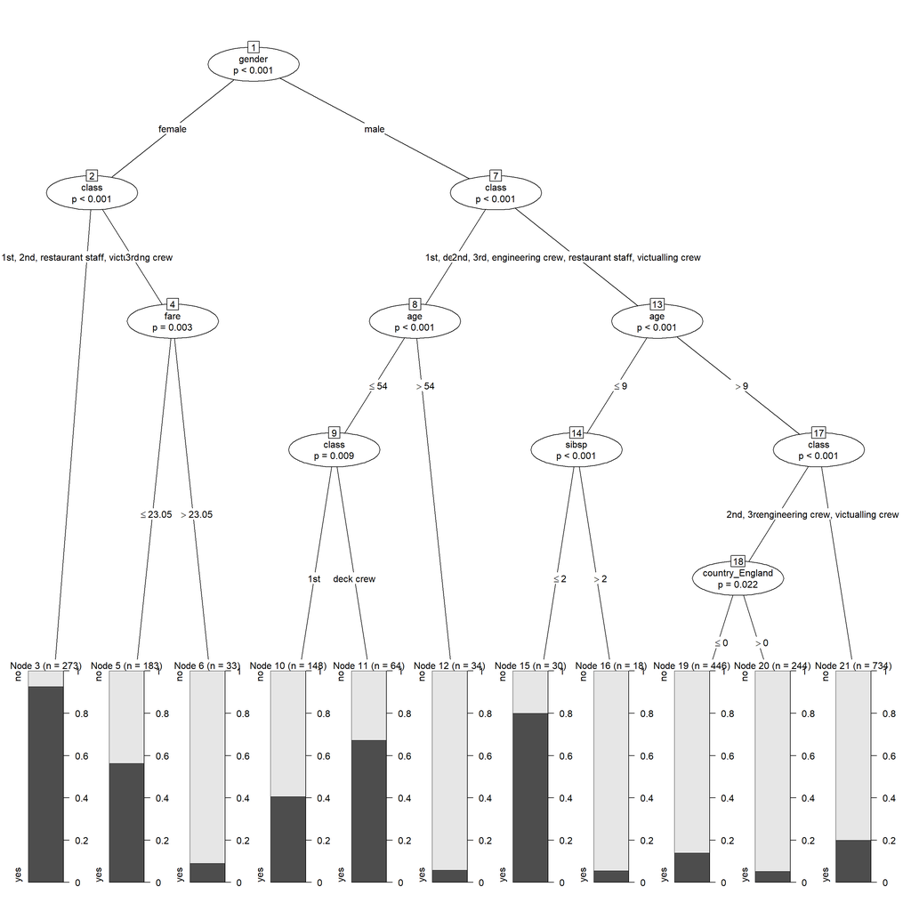

```r
library("fastDummies")
dataOne <- fastDummies::dummy_cols(data, select_columns = "country")
dataOne <- select(dataOne, -country)
 ctree1 <- partykit::ctree(survived~.,data = dataOne)

    plot(ctree1)
```

Wyniki bez strojenia i postać drzewa. Widzimy, że już z domyślnymi hiperparametrami algorytm osiąga bardzo dobre wyniki pod względem `AUC`.

```r
classif_task = makeClassifTask(id = "task", data = data, target = "survived")
classif_lrn = makeLearner("classif.ctree", predict.type = "prob")

num_ps = makeParamSet(
  makeIntegerParam("mtry", lower = 0, upper = 8),
  makeIntegerParam("maxdepth", lower = 1, upper = 30),
  makeIntegerParam("minbucket", lower = 1, upper = 60),
  makeIntegerParam("minsplit", lower = 1, upper = 60)
)



ctrl = makeTuneControlRandom(maxit = 50L)
rdesc = makeResampleDesc("CV", iters = 5L)



res5C = tuneParams(classif_lrn, task = classif_task, resampling = rdesc,
                  par.set = num_ps, control = ctrl, measures = list(auc,acc))

res5C
```

```
## Tune result:
## Op. pars: mtry=7; maxdepth=7; minbucket=6; minsplit=31
## auc.test.mean=0.8012293,acc.test.mean=0.7992797
```

Wyniki po `random search`.

## 5.2 Rpart

```r
classif_task = makeClassifTask(id = "task", data = data, target = "survived")
classif_lrn = makeLearner("classif.rpart", predict.type = "prob")

num_ps = makeParamSet(
  makeIntegerParam("maxdepth", lower = 1, upper = 30),
  makeIntegerParam("minbucket", lower = 1, upper = 60),
  makeIntegerParam("minsplit", lower = 1, upper = 60)
)



ctrl = makeTuneControlRandom(maxit = 50L)
rdesc = makeResampleDesc("CV", iters = 5L)



res5R = tuneParams(classif_lrn, task = classif_task, resampling = rdesc,
                  par.set = num_ps, control = ctrl, measures = list(auc,acc))

res5R
```

```
## Tune result:
## Op. pars: maxdepth=25; minbucket=1; minsplit=29
## auc.test.mean=0.7758384,acc.test.mean=0.8056002
```

W tym konkretnym porównaniu `ctree` poradziło sobie podobnie do `rpart` pod względem `ACC`, lecz znacznie lepiej pod względem `AUC`, znacząco prześcigając `rpart`. Algorytm Conditional Inference Trees uzyskał nawet lepsze wyniki od przedstawianego wcześniej optymalnego zestawu parametrów.